# GxEScanR: An R Package to Detect GxE Interactions in a Genome-wide Association Study

*Version: 1.0*  
*October 2018*

##### Developed by:

- John Morrison, M.S. (JMorr@usc.edu)
- Andre E. Kim, Ph.D. (Andreeki@usc.edu)
- Jim Gauderman, Ph.D. (JimG@usc.edu)

##### Acknowledgements

Supported in part by NCI grants PO1-CA196569 and RO1-CA201407 and NIEHS grant P30-ES007048.

##### Reference, software

1. Morrison, J, Kim AE, Gauderman J. GxEScanR: An R package to detect GxE interactions in a genomewide association study, Version 1.0. University of Southern California, Los Angeles; October, 2018. http://Github.com/USCBiostats/GxEScanR

##### References, methods

2. Gauderman J, Mukherjee B, Aschard H, Hsu L, Lewinger JP, Patel C, Witte J, Amos C, Tai C, Conti D, Torgerson D, Lee S, Chatterjee N. Update on the State of the Science for Analytical Methods for Gene-Environment Interactions. Am J Epidemiol 186:762-70, 2017.
3. Gauderman J, Zhang P, Morrison J, Lewinger JP. Finding Novel Genes by Testing GxE Interactions in a Genomewide Association Study. Genetic Epidemiology, 37:603-613, 2013.

*Thank you for using GxEScanR for your GxE interation analysis.*  
*We would appreciate hearing about any errors you might find or comments you might have to improve the program. Please e-mail questions/comments to Jim Gauderman.*

# General Description

GxEScanR is an R package that performs a genomewide scan for gene-environment (GxE) interaction for a disease trait. The program implements the traditional test of GxE interaction in a case-control sample, the case-only test of GxE interaction, the 2-degree-of-freedom (df) joint test of G and GxE, and efficient 2-step methods for tests of either GxE or joint G & GxE<sup>1</sup>. As a byproduct of the available tests, GxEScanR also produces results for the standard marginal G scan, i.e. the standard test of each SNP conducted in a GWAS.

The ‘environment’ factor E in the GxE scans may be either binary or continuous and can be an exogenous exposure variable (e.g., sunlight, air pollution), personal exposure (e.g., smoking, dietary fat), or other personal characteristic (e.g., sex, age, candidate gene). GxEScanR will test GxE interaction with measured and/or imputed SNPs on autosomal chromosomes and will control the family-wise error rate (FWER) at a user-defined level (e.g. 5%).

GxEScanR utilizes C++ (via RCpp) to improve computational speed. The program also reads binary-formatted imputed SNP files which further improves speed. A companion program, BinaryDosage, is available to convert VCF or IMPUTE2 imputed SNP files into the binary format required by GxEScanR. The BinaryDosage program should be used before using GxEScanR.

### Functions

- **GetBinaryDosageInfo** - Create R List containing BDose file attributes (required for *GxEScan*)
- **GxEScan** - Run GWAS/GWIS (See below)

### Program Outputs

GxEScanR produces a single text-formatted output file that includes the SNP identifier and the effect estimate and test statistic for all of the tests described below.

##### Output statistics

- **BetaG/zG**: Marginal G (CC_DG) association
- **BetaGxE/zGxE**: GxE (CC_GxE) interaction
- **Chi2df**: Joint G, GxE (CC_2df) association
- **Beta_Case/z_Case**: Case-only G-E association (Case_GE)
- **Beta_Control/z_Control**: Control-only G-E association (Cntl_GE)
- **Beta_GE/z_GE**: Overall G-E association in cases and controls combined (CC_GE)

These statistics can be used to generate QQplots and/or Manhattan plots using your favorite R program or other software. A companion R package that will generate QQplots and Manhattan plots for all of the tests generated by GxEScanR is currently under construction.

With additional R coding (at this point on your own) the above statistics can be used to generate the CC_3df test (see Section 2.5) or any of the 2-step procedures (see Section 2.6). A companion R Package that will read GxEScanR output and generate the 3-df and 2-step tests described above is currently under construction.

### Installation

1. Install the devtools package
2. Install the GxEScanR package directly from the USCbiostats repository on GitHub:

```r
library(devtools)
install_github("USCbiostats/GxEScanR")

library(GxEScanR)
```

### Example

Use example BDose and dummy covariate file provided in GitHub repository.

##### Run GxEScan

```r
library(GxEScanR)

# Read dummy phenotype file
cov <- read.table("example_pheno.txt", stringsAsFactors = F, header = T)
bdose <- GxEScanR::GetBinaryDosageInfo("example.bdose")
GxEScan(cov, bdose, "example_results.out")
```

##### Results - Output File

```r
library(qqman)
library(kableExtra)

results <- read.table("example_results.out", stringsAsFactors = F, header = T)

# Calculate P values from Z statistics
results$zP <- 2 * pnorm(-abs(results$zG))
results$zGxEP <- 2 * pnorm(-abs(results$zGxE))

# View results data.frame
kable(head(results)) %>% kable_styling(bootstrap_options = "condensed", full_width = F,
    position = "left", font_size = 11) %>% scroll_box(width = "800px", height = "350px")
```

| CHR | SNP | BP | A1 | A2 | Cases | Controls | BetaG | zG | BetaGxE | zGxE | Chi2df | GEModel | Beta_GE | z_GE | OnlyModel | Beta_Case | z_Case | Beta_Ctrl | z_Ctrl | zP | zGxEP |
| --- | --- | --- | --- | --- | --- | --- | --- | --- | --- | --- | --- | --- | --- | --- | --- | --- | --- | --- | --- | --- | --- |
| 1 | 1:10576_C_A | 10576 | C | A | 1000 | 1000 | -0.0005734 | -0.0047828 | 0.4791060 | 1.834320 | 3.364740 | H | 0.5466980 | 2.025500 | H | 0.2451120 | 0.6644790 | 0.806754 | 1.9129100 | 0.9961839 | 0.0666065 |
| 1 | 1:10943_A_T | 10943 | A | T | 1000 | 1000 | 0.0359020 | 0.5002750 | 0.1446030 | 0.927959 | 1.111430 | H | 0.0641318 | 0.394248 | H | 0.0067235 | 0.0304801 | -0.190633 | -0.5606990 | 0.6168815 | 0.3534288 |
| 1 | 1:11309_G_T | 11309 | G | T | 1000 | 1000 | -0.8692020 | -7.9112700 | -0.6240100 | -2.581100 | 65.350300 | H | -0.1849520 | -0.878347 | H | -1.3987400 | -4.0161000 | -16.827200 | -0.0184147 | 0.0000000 | 0.0098486 |
| 1 | 1:10614_G_C | 10614 | G | C | 1000 | 1000 | -0.2075120 | -1.7158800 | -0.1004060 | -0.378719 | 3.073350 | H | 0.1768990 | 0.710527 | H | 0.1188290 | 0.3597920 | 0.137381 | 0.2846310 | 0.0861840 | 0.7048965 |
| 1 | 1:11396_G_T | 11396 | G | T | 1000 | 1000 | -0.0694808 | -0.6439030 | 0.0494758 | 0.210464 | 0.459181 | H | 0.1188810 | 0.509855 | H | 0.2536370 | 0.8125970 | -0.400742 | -0.7105080 | 0.5196383 | 0.8333055 |
| 1 | 1:11877_A_T | 11877 | A | T | 1000 | 1000 | 0.0078403 | 0.1007370 | 0.3087200 | 1.823920 | 3.337190 | H | 0.0243699 | 0.142368 | H | 0.1147340 | 0.5062920 | -0.120045 | -0.3379250 | 0.9197592 | 0.0681642 |

##### Results - Plots

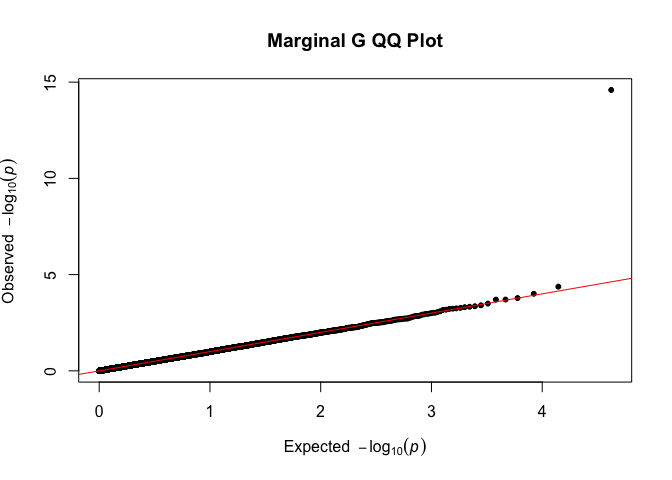

```r
qq(results$zP, main = "Marginal G QQ Plot")
```

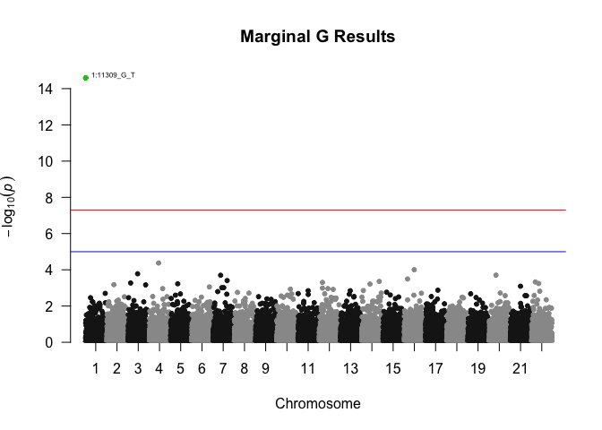

```r
manhattan(results, chr = "CHR", bp = "BP", p = "zP", snp = "SNP", main = "Marginal G Results",
    highlight = "1:11309_G_T", annotatePval = 5e-08)
```

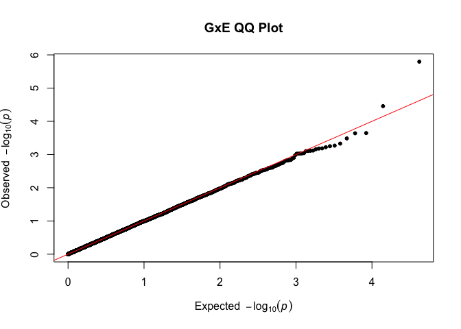

```r
qq(results$zGxEP, main = "GxE QQ Plot")
```

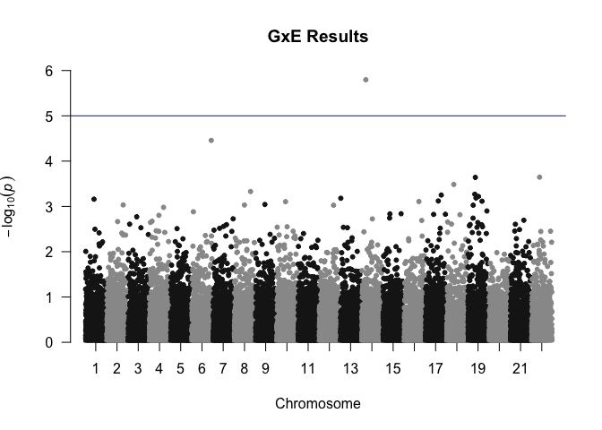

```r
manhattan(results, chr = "CHR", bp = "BP", p = "zGxEP", main = "GxE Results")
```

# Methods

## 1. Notation

We assume the data are derived from a case-control study in which cases and controls are unrelated (i.e. not a family-based design). The following notation will be used throughout this documentation:

**D**: Disease status (1=case, 0=control)

**E**: Environmental factor of interest, which can be binary or continuous, e.g.  
• Indicator of exposure (e.g. 1=Exposed, 0=Unexposed)  
• Indicator of sex (e.g. 1=Female, 0=Male)  
• Quantitative exposure (e.g. pack-years of tobacco smoking)  
• Personal factor (e.g. age)  
• Candidate locus genotype (e.g. 0, 1, or 2 variant alleles)

**C**: A set of adjustment covariates, which can be binary and/or continuous variables (optional)

**D**, **E**, and **C** must be in a single R data frame that also includes a unique subject identifier. This identifier is used to link the **D**, **E**, and **C** data to the subject’s corresponding SNP data.

**G**: Imputed genotype “dosage” at one of M SNPs being scanned for GxE interaction. Only SNPs on autosomal chromosomes can be analyzed. We assume that the goal is to analyze the M SNPs to identify one or more disease susceptibility loci (DSL). We assume the underlying genotype for each SNP is biallelic, with possible genotype 0 (two major alleles), 1 (heterozygous), or 2 (two minor alleles). For each SNP, the imputed dosage is assumed to be a value between 0 and 2 representing the expected number of minor alleles. In addition to dosage, the imputation program may also provide genotype probabilities p0, p1, p2, the probabilities of genotype 0, 1, or 2, respectively. The BinaryDosage program (see Introduction) will read the available data from a VCF- or IMPUTE2-formatted file and generate dosages (and possibly genotype probabilities) in the binary format required by GxEScanR.

## 2. Models: Disease Trait

**2.1 Marginal** **Test (CC_DG association)**: In a case-control study, the marginal effect of a SNP (

[figure not shown]

) on disease (

[figure not shown]

) with possible adjustment for covariates (

[figure not shown]

) is typically measured by the genetic odds ratio

[figure not shown]

, which can be obtained as

[figure not shown]

from a logistic regression model of the form:

[figure not shown]

A standard GWAS of marginal effects is conducted by testing the null hypothesis

[figure not shown]

for each of M SNPs in turn, with corresponding test statistic

[figure not shown]

. Note that because

[figure not shown]

is scaled from 0 to 2,

[figure not shown]

represents the odds ratio per increase of one allele, for example the OR comparing a heterozygote to a homozygous normal. One typically adopts a strict significance level (e.g. 5 x 10-8) to preserve the family-wise error rate (FWER).

**2.2 Interaction Test** **(CC_GxE association)**: In a second genomewide scan, one could augment the model in Equation 1 to test each SNP in turn for GxE interaction using the model:

[figure not shown]

A genomewide interaction scan is based on testing the null hypothesis

[figure not shown]

using test statistic

[figure not shown]

for each SNP in turn, with strict significance level to preserve the FWER. The quantity

[figure not shown]

is the interaction odds ratio, e.g. the genetic effect in exposed individuals relative to the genetic effect in unexposed (

[figure not shown]

).

**2.3 Interaction Test** **(Case_GE)**: A more powerful test of GxE interaction can be obtained using a case-only analysis, in which “GE” association is tested between

[figure not shown]

and each SNP in affected individuals<sup>2</sup>. GxEScanR models

[figure not shown]

as a function of

[figure not shown]

, based on the polytomous logistic model:

[figure not shown]

If

[figure not shown]

and

[figure not shown]

are independent in the population, the quantity

[figure not shown]

is a consistent estimator of the GxE relative risk ratio<sup>2</sup> and the Wald test of

[figure not shown]

is asymptotically equivalent to testing

[figure not shown]

in Model 2. Although a case-only analysis can be substantially more powerful than a case-control analysis<sup>3</sup>, it depends critically on the assumption of population-level G-E independence. For some SNPs, there may not be sufficient sample size within each genotypic group to estimate both

[figure not shown]

and

[figure not shown]

, so that estimates and tests cannot be obtained. GxEScanR will detect this situation and for such a SNP will fit an alternative allelic model of the form

[figure not shown]

where an allele A can have value 0 or 1 and the SNP genotype is constructed from two such alleles. GxEScanR forms the corresponding likelihood for G assuming Hardy Weinberg equilibrium. SNPs for which the model in Eq 3 does not converge often will converge using the model in Eq 4.

For imputed SNP data, GxEScanR forms the likelihood contribution for each subject based on Model 3 (if genotype probabilities are available) or Model 4 (if allele dosage values are available).

GxEScanR also generates results from applying Model 3 or 4 to the subset of Controls Only (Cntl_GE, based on unaffected subjects). While this does not provide a test of GxE interaction, it can provide useful results for examining whether there is general G-E association that might be due to factors other than GxE interaction.

**2.4 Joint G, GxE Test** **(CC_2df)**: Kraft et al.<sup>4</sup> demonstrated that a test of joint null hypothesis

[figure not shown]

based on the model in Eq 2 can sometimes provide greater power to detect a DSL than either the marginal DG test or the case-control GxE test alone. This test has 2 degrees of freedom (2 df) provided G and E are each coded using a single variable. Note that the joint test evaluates a fundamentally different null hypothesis than the GxE-alone tests and in practice will produce different SNPs on the top lists.

[figure not shown]

[figure not shown]

, T3 has a chi-squared distribution with 3 degrees of freedom.

**2.6 Two-Step Procedures** : Several two-step methods have been proposed to conduct a genomewide GxE scan<sup>5</sup>. All of these procedures generally provide greater power than a case-control GxE analysis while preserving the Type I error rate. Some 2-step methods can achieve greater power than a case-only analysis.

A key requirement for any of the two-step methods is independence of the Step-1 screening and Step-2 testing statistics. The 2-step methods described below all have this independence, and the component statistics required to form the corresponding tests are all generated by GxEScanR. The Step 2 test for each of the procedures below can be evaluated for significance based on ‘subset-testing’ or ‘weighted hypothesis testing’ (see Section 3). A separate R package (under construction) will generate results for both the subset and weighted approaches for all of the procedures below.

- **2.6.1 2-Step, screening on D-G association** **(DG | GxE)**: Kooperberg and LeBlanc<sup>6</sup> proposed a 2-step procedure that uses the marginal DG association statistic

[figure not shown]

  to screen SNPs at Step-1 significance level

[figure not shown]

  . They proposed testing the subset m << M SNPs that pass the Step-1 screen using Step-2 test statistic

[figure not shown]

  , with Bonferroni-corrected significance level

[figure not shown]

  to preserve the FWER. We denote their method DG|GxE.
- **2.6.2 2-Step, screening on G-E correlation** **(GE | GxE)**: Murcray et al.<sup>5</sup> demonstrated that in the presence of GxE interaction, there is an induced correlation between G and E in the combined case-control sample. In other words, based on the model

[figure not shown]

- applied to the full sample of cases and controls, one can typically expect

[figure not shown]

  in the presence of GxE interaction. They proposed using test statistic

[figure not shown]

  (labelled CC_GE) of

[figure not shown]

  as a Step 1 screen at significance level

[figure not shown]

  . They proposed testing the subset m << M SNPs that pass the screen using Step-2 test statistic

[figure not shown]

  at significance level

[figure not shown]

  . GxEScanR implements this ‘subset-testing’ approach as well as a modification that uses ‘weighted hypothesis testing’ in Step 2 (see 3). The use of the model in Eq 5 rather than the case-only model in Eq 3 preserves the necessary independence between Steps 1 and 2. As for a case-only analysis, the modified model with form shown in Eq 4 will be applied to a SNP for which the model in Eq 5 does not converge or if a single dosage value is provided based on imputation.
- **2.6.3 2-Step, screening on DG and GE** **(EDGE)**: This approach, developed by Gauderman et al.<sup>10</sup>, provides a more efficient screen by using all available surrogate information in a single Step-1 screening test. The name EDGE derives from gE+Dg screening followed by GxE testing. Specifically, for each of the M SNPs, one computes

[figure not shown]

  , (labelled CC_DGGE) i.e. the sum of the DG and GE screening statistics. Under the null hypothesis of no GxE interaction,

[figure not shown]

  and

[figure not shown]

  are independent<sup>11</sup>, and each follows a central chi-squared distribution with 1 degree of freedom (df) under their respective null hypotheses. Thus,

[figure not shown]

  follows a central chi-squared distribution with 2 df. The Step-2 test is based on

[figure not shown]

  . We advocate using ‘weighted hypothesis testing’ in Step 2 rather than ‘subset testing’, although both approaches are supported in GxEScanR. We have demonstrated that this method typically provides greater power than any of the above 2-step methods, particularly for a gene with a weak marginal (DG) association<sup>10</sup>.

## 3. Step-2 Hypothesis Testing Approaches

GxEScanR generates the necessary statistics to facilitate two approaches to hypothesis testing in Step 2 for all of the two-step methods.

a. Subset Testing: Test only a subset m << M SNPs that have

[figure not shown]

from the Step 1 screen, with Step 2 significance level

[figure not shown]

(i.e. a Bonferroni correction for the number of SNPs that pass Step 1). Here the analyst must specify

[figure not shown]

. A larger value of

[figure not shown]

will increase the chance of passing a DSL into Step 2, but at the cost of also increasing the number of unassociated SNPs that pass into Step 2. A lower value of

[figure not shown]

leads to lower

[figure not shown]

and thus greater power in Step 2, but at the potential cost of screening out a DSL. The optimal choice of

[figure not shown]

depends strongly on M but also on other underlying parameters (e.g. minor allele frequency of a DSL, exposure frequency, magnitude of an interaction, etc.). As a general rule, we have found that setting

[figure not shown]

so that between m=25 and m=200 SNPs pass into Step 2 is near optimal for many models. For example, if M=1 million, setting

[figure not shown]

to 0.0001 would yield approximately m=100 SNPs to be tested in Step 2.

b. Weighted Hypothesis Testing: Rather than restrict Step-2 testing to a subset of the SNPs, one can test all M SNPs using a weighted significance level in Step 2 based on the ordered p-values from Step 1 and an initial bin size B<sup>12</sup>. Specifically, the B most significant (lowest p-value) SNPs based on Step 1 are evaluated in Step 2 at significance level

[figure not shown]

, the next 2B SNPs are evaluated at

[figure not shown]

, the next 4B at

[figure not shown]

, etc. As shown by Ionita-Laza et al.<sup>12</sup>, this guarantees that the overall significance level for the entire procedure does not exceed

[figure not shown]

. They recommended setting B to 5. When B=5 the top 5 SNPs from Step 1 are tested in Step 2 at significance level 0.005, the next 10 at 0.00125, etc. Note that with weighted testing the top SNPs from Step 1 are tested at a more liberal (less strict) significance threshold than the standard 5 x 10-8 level required in an exhaustive scan of all M SNPs using standard methods. However, the majority of SNPs will be tested at a significance level that is more stringent than 5x10-8. This indicates the importance of using an efficient Step-1 screening approach with strong likelihood of highly ranking any SNP with a true interaction. As an example, across many simulation scenarios for a disease outcome, we have found the Step-1 screen of the EDGxE method tends to rank true signals higher than the corresponding Step-1 screens of alternative 2-step methods.

# References

1. Gauderman, W. J. *et al.* Update on the State of the Science for Analytical Methods for Gene-Environment Interactions. *American Journal of Epidemiology* **186,** 762–770 (2017).

2. Piegorsch, W. W., Weinberg, C. R. & Taylor, J. A. Non-hierarchical logistic models and caseonlydesigns for assessing susceptibility in population-based case-control studies. *Statistical Medicine* **13,** 153–162 (1994).

3. Yang, Q., Khoury, M. J. & Flanders, W. D. Sample size requirements in case-only designs to detect gene-environment interaction. *American Journal of Epidemiology* (1997). doi:10.1093/oxfordjournals.aje.a009346

4. Kraft, P., Yen, Y. C., Stram, D. O., Morrison, J. & Gauderman, W. J. Exploiting gene-environment interaction to detect genetic associations. *Human Heredity* **63,** 111–119 (2007).

5. Murcray, C. E., Lewinger, J. P. & Gauderman, W. J. Gene-environment interaction in genome-wide association studies. *American Journal of Epidemiology* **169,** 219–226 (2009).

6. Kooperberg, C. & LeBlanc, M. Increasing the power of identifying gene x gene interactions in genome-wide association studies. *Genetic Epidemiology* **32,** 255–263 (2008).

7. Li, D. & Conti, D. V. Detecting gene-environment interactions using a combined case-only and case-control approach. *American Journal of Epidemiology* **169,** 497–504 (2009).

8. Murcray, C. E., Lewinger, J. P., Conti, D. V., Thomas, D. C. & Gauderman, W. J. Sample size requirements to detect gene-environment interactions in genome-wide association studies. *Genetic Epidemiology* (2011). doi:10.1002/gepi.20569

9. Hsu, L. *et al.* Powerful cocktail methods for detecting genome-wide gene-environment interaction. *Genetic epidemiology* **36,** 183–194 (2012).

10. Gauderman, W. J., Zhang, P., Morrison, J. L. & Lewinger, J. P. Finding Novel Genes by Testing G × E Interactions in a Genome-Wide Association Study. *Genetic Epidemiology* **37,** 603–613 (2013).

11. Dai, J. Y., Kooperberg, C., Leblanc, M. & Prentice, R. L. Two-stage testing procedures with independent filtering for genome-wide gene-environment interaction. *Biometrika* **99,** 929–944 (2012).

12. Ionita-Laza, I., McQueen, M. B., Laird, N. M. & Lange, C. Genomewide Weighted Hypothesis Testing in Family-Based Association Studies, with an Application to a 100K Scan. *American Journal of Human Genetics* **81,** 607–614 (2007).